# R Notebook

```r
library(readr) #Membaca data
library(dplyr) #Data processing
library(DT) #Menampilkan tabel agar mudah dilihat di browser
library(readxl)
dataset <- read_csv("G:/download chrome/miskin_jatim.csv")
dataset
```

| Kabupaten | AHH | AMH | RLS | Pengeluaran | P1 |
| --- | --- | --- | --- | --- | --- |
| Pacitan | 72.18 | 92.57 | 7.01 | 7686 | 16.73 |
| Ponorogo | 70.85 | 89.11 | 7.49 | 8654 | 11.92 |
| Trenggalek | 72.33 | 94.41 | 7.33 | 8445 | 13.56 |
| Tulungagung | 72.02 | 96.84 | 7.97 | 9534 | 9.07 |
| Blitar | 71.80 | 94.49 | 7.41 | 9272 | 10.57 |
| Kediri | 70.65 | 95.04 | 7.75 | 9883 | 13.23 |
| Malang | 69.70 | 93.94 | 7.08 | 8845 | 11.48 |
| Lumajang | 67.95 | 89.22 | 6.52 | 7921 | 12.14 |
| Jember | 63.64 | 88.42 | 6.80 | 8255 | 11.68 |
| Banyuwangi | 68.58 | 91.36 | 7.25 | 10692 | 9.61 |

[output cut: 28 more lines]

```r
dataset[,2:6] <- scale(dataset[,2:6])
dataset
```

| Kabupaten | AHH | AMH | RLS | Pengeluaran | P1 |
| --- | --- | --- | --- | --- | --- |
| Pacitan | 0.96944170 | 0.03527505 | -0.51450392 | -1.04416639 | 0.80439827 |
| Ponorogo | 0.54772038 | -0.63301940 | -0.20105865 | -0.72492992 | -0.11896991 |
| Trenggalek | 1.01700426 | 0.39066863 | -0.30554040 | -0.79385598 | 0.19585833 |
| Tulungagung | 0.91870831 | 0.86001994 | 0.11238663 | -0.43471495 | -0.66607996 |
| Blitar | 0.84894989 | 0.40612053 | -0.25329953 | -0.52111986 | -0.37812731 |
| Kediri | 0.48430364 | 0.51235230 | -0.03127579 | -0.31961833 | 0.13250874 |
| Malang | 0.18307412 | 0.29988875 | -0.46879315 | -0.66194008 | -0.20343603 |
| Lumajang | -0.37182236 | -0.61177305 | -0.83447930 | -0.96666580 | -0.07673686 |
| Jember | -1.73845312 | -0.76629200 | -0.65163623 | -0.85651603 | -0.16504234 |
| Banyuwangi | -0.17205963 | -0.19843486 | -0.35778128 | -0.05281843 | -0.56241701 |

[output cut: 28 more lines]

# Agglomerative Hierarchical Clustering

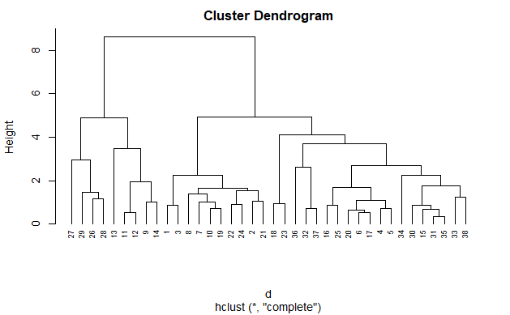

```r
# Matriks Distance/Jarak (Package stats)
# pilihan method: euclidean (default), maximum, manhattan, canberra, binary, minkowski
d <- dist(dataset, method = "euclidean")
# pilihan method: complete (default), average, single, ward.D, ward.D2, median, centroid, mcquitty
hc <- hclust(d, method = "complete")

plot(hc, cex = 0.6, hang = -1)
```

```r
# abline(h=3.5, col="red")
```

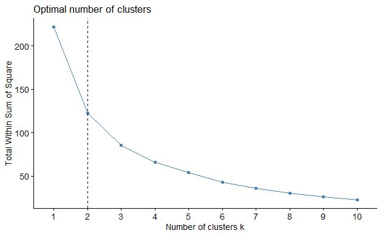

```r
set.seed(1)
fviz_nbclust(dataset, hcut, method = "wss") +
  geom_vline(xintercept = 2, linetype = 2)
```

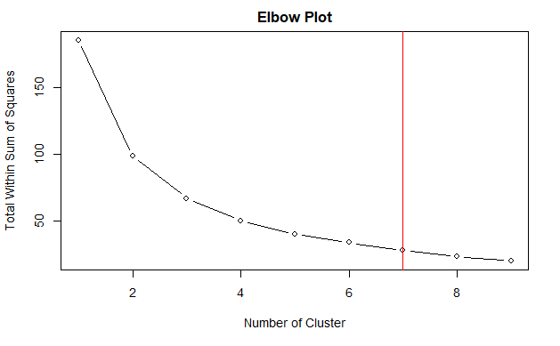

```r
jumlah_klaster <- c(1:9) #Vektor yang berisikan jumlah klaster yang ingin dilihat nilai dari total within-cluster sum of squares
within_ss <- c() #Vektor kosong yang akan diisi nilai total within- cluster sum of squares
for (i in jumlah_klaster) {
  within_ss <- c(within_ss, kmeans(x = dataset[2:6], centers = i, nstart = 25)$tot.withinss)
}
plot(x = jumlah_klaster, y = within_ss, type = "b", xlab = "Number of Cluster",ylab = "Total Within Sum of Squares",main = "Elbow Plot" )
abline(v = 7, col = 'red')
```

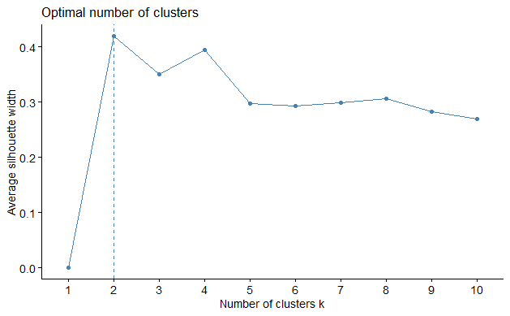

```r
fviz_nbclust(dataset, hcut, method = "silhouette")
```

```
Clustering k = 1,2,..., K.max (= 10): .. done
Bootstrapping, b = 1,2,..., B (= 100)  [one "." per sample]:
.................................................. 50
.................................................. 100
```

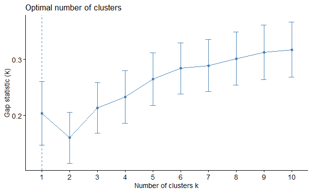

```r
fviz_nbclust(dataset[2:6], hcut, method = "gap_stat")
```

```r
dist_data <- dist(dataset[2:6],method = "euclidean")
dist_data
```

[output not shown]

[output cut: 58 more lines]

[output not shown]

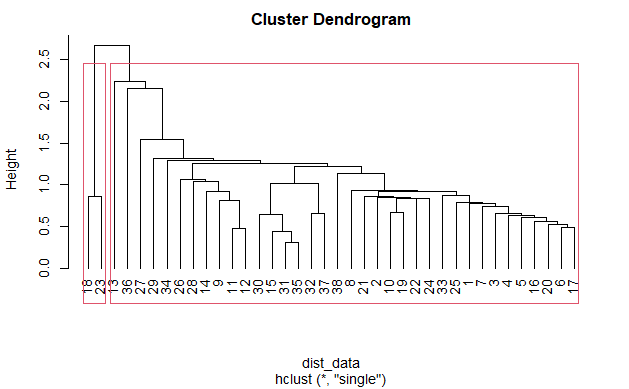

```r
res1_par <- hclust(dist_data, method = "single")
plot(res1_par,hang=-2,cex=1)
rect.hclust(res1_par,k=2)
```

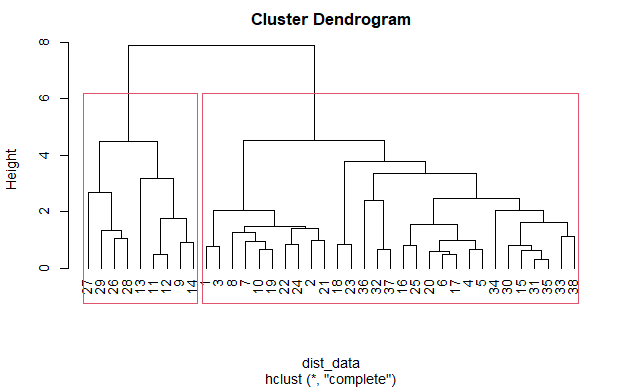

```r
res1_par <- hclust(dist_data, method = "complete")
plot(res1_par,hang=-2,cex=1)
rect.hclust(res1_par,k=2)
```

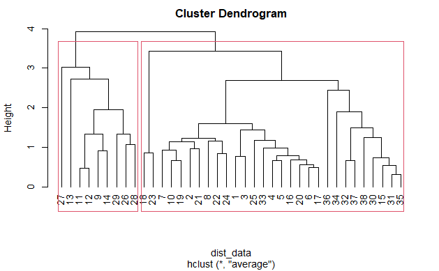

```r
res1_par <- hclust(dist_data, method = "average")
plot(res1_par,hang=-2,cex=1)
rect.hclust(res1_par,k=2)
```

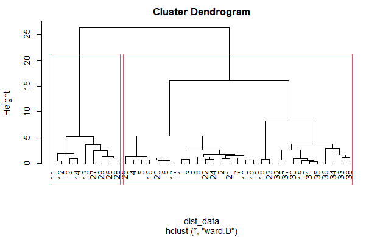

```r
res1_par <- hclust(dist_data, method = "ward.D")
plot(res1_par,hang=-2,cex=1)
rect.hclust(res1_par,k=2)
```

untuk single linkage, 2 cluster masih buruk karena terdapat 1 cluster yang berisi hanya 2 kabupaten.

untuk complete linkage,average linkage, dan ward cukup baik karena pada pembagian 2 cluster cluster 1 terdapat 9 kabupaten sedangkan 29 kabupaten cluster 2 yaitu cluster 1 adalah 9,11,12,13,14,26,27,28,29 sedangkan cluster 2 sisanya.

#evaluasi

```r
sub_grp <- cutree(res1_par, k=2)
stat <- cluster.stats(dist_data, sub_grp) # Statistik dari Klaster

stat$clus.avg.silwidths # Silhouette per klaster
```

```
        1         2
0.2734828 0.7727303
```

```r
stat$avg.silwidth # Rata-rata Silhouette seluruhnya
```

```
[1] 0.299759
```

```r
stat$dunn # Indeks Dunn
```

```
[1] 0.3386908
```

```r
stat$dunn2 # Indeks Dunn versi lain
```

```
[1] 1.384465
```

```r
stat$entropy # Entropi
```

```
[1] 0.2061921
```

```r
stat$ch # Indeks Calinski and Harabasz
```

```
[1] 4.130142
```

```r
stat$sindex # Separation index
```

```
[1] 2.704747
```

```r
stat$wb.ratio # average.within/average.between
```

```
[1] 0.696238
```

```r
set.seed(123)
kmeans_clustering <- kmeans(x = dataset[2:6], centers = 2,
nstart = 25) #parameter nstart digunakan untuk memberitahu fungsi berapa kali inisiasi centroid awal (secara acak) yang akan dibentuk.
kmeans_clustering
```

```
K-means clustering with 2 clusters of sizes 11, 27

Cluster means:
         AHH        AMH        RLS Pengeluaran         P1
1 -1.3524758 -1.1503067 -1.0701569  -0.6468597  0.9314465
2  0.5510087  0.4686435  0.4359899   0.2635354 -0.3794782

Clustering vector:
 [1] 2 2 2 2 2 2 2 1 1 2 1 1 1 1 2 2 2 2 2 2 2 1 2 2 2 1 1 1 1 2 2 2 2 2 2 2 2 2

Within cluster sum of squares by cluster:
[1] 26.98794 71.56885
 (between_SS / total_SS =  46.7 %)

Available components:

[1] "cluster"      "centers"      "totss"        "withinss"     "tot.withinss" "betweenss"
[7] "size"         "iter"         "ifault"
```

Pengelompokan objek ke dalam 2 klaster berdasarkan nilai centroid dari masing-masing variabel. Objek objek dengan nilai centroid yang hampir sama akan dikelompokkan dalam satu klaster sehingga didapat pembagian klasternya sebagai berikut

Dari output diatas dapat di ketahui bahwa klaster pertama beranggotakan 11 observasi, klaster kedua 27 observasi. Dilihat dari means nya, cluster 1 merupakan wilayah jatim yang miskin (AHH,AMH,RLS,Pengeluaran rendah dan tingkat kemiskinan P1 Tinggi), sedangkan cluster 2 merupakan wilayah jatim yang tidak miskin (AKK,AMH,RLS,Pengeluaran tinggi, P1 kemiskinan rendah)

```r
stat <- cluster.stats(d, kmeans_clustering$cluster) # Statistik dari Klaster

stat$clus.avg.silwidths # Silhouette per klaster
```

```
       1        2
0.410400 0.410885
```

```r
stat$avg.silwidth # Rata-rata Silhouette seluruhnya
```

```
[1] 0.4107446
```

```r
stat$dunn # Indeks Dunn
```

```
[1] 0.1875873
```

```r
stat$dunn2 # Indeks Dunn versi lain
```

```
[1] 1.766312
```

```r
stat$entropy # Entropi
```

```
[1] 0.6016798
```

```r
stat$ch # Indeks Calinski and Harabasz
```

```
[1] 31.57525
```

```r
stat$sindex # Separation index
```

```
[1] 1.029491
```

```r
stat$wb.ratio # average.within/average.between
```

```
[1] 0.5661471
```

```r
library(dplyr)
data_baru <- dataset %>% mutate(Klaster = kmeans_clustering$cluster)
data_baru <- data_baru[,c(1,7)]
data_baru %>% arrange(Klaster)
```

| Kabupaten | Klaster |
| --- | --- |
| Lumajang | 1 |
| Jember | 1 |
| Bondowoso | 1 |
| Situbondo | 1 |
| Probolinggo | 1 |
| Pasuruan | 1 |
| Bojonegoro | 1 |
| Bangkalan | 1 |
| Sampang | 1 |
| Pamekasan | 1 |

[output cut: 28 more lines]

Kota Lumajang, Jember, Bondowoso, Situbondo, Probolinggo, Pasuruan, Bojonegoro, Bangkalan, Sampang, Pamekasan, dan Sumenep merupakan kabupaten yang masuk ke cluster 1 dan dapat dikategorikan kabupaten miskin.